# Nonmetric multidimentional scaling - Anderson et al 2011

Laurence Dumouchel

April 11, 2015

Anderson et al 2011 - INITIAL RADIATION OF JAWS DEMONSTRATED STABILITY DESPITE FAUNAL AND ENVIRONMENTAL CHANGE

Summary: This paper presents a summary of the evolution of jaw morphology of gnathostomes (vertebrates with bony jaws) through time, as the agnathostomes (fish without jaws like lampreys) became less and less common. The authors scored jaws from almost 200 genera according to 31 continuous and discontinuous traits.

*Read in the data*

```r
fish<-read.table("http://hompal-stats.wabarr.com/datasets/Anderson_etal_2011_fish.csv", sep=",", header=T, na.strings="NA")
head(fish)
```

```
##        Group         Genus Stratigraphic.range      C1      C2      C3
## 1 Acanthodii  Atopacanthus                 Giv 0.16500 0.53300 0.21000
## 2 Acanthodii Brochoadmones                 Loc 0.25000 0.45800      NA
## 3 Acanthodii   Cassidiceps                 Loc 0.27000 0.52100 0.17300
## 4 Acanthodii Cheiracanthus                 Eif 0.17375 0.45375 0.18675
## 5 Acanthodii  Diplacanthus                 Eif 0.21000 0.56300 0.19900
## 6 Acanthodii     Climatius                 Sil 0.25700 0.42100 0.33700
##         C4        C5       C6        C7    C8    C9        C10 C11 D1 D2
## 1 0.126000 0.0446000 0.699000 0.1670000 0.645 0.282 0.03630000  53  1 NA
## 2       NA 0.0635000 0.454000 0.1640000 1.500 0.123 0.07940000  65  0  1
## 3 0.158000 0.0994000 0.584000 0.1990000 0.000 0.000 0.05650000  52  0  0
## 4 0.147375 0.0804375 0.605625 0.2005714 0.000 0.000 0.07477143  48  0  0
## 5 0.139000 0.0850000 0.477000 0.2890000 0.000 0.000 0.05670000  37  0  0
## 6 0.253000 0.0603000 0.261000 0.3370000 1.221 0.118 0.07490000  52  0  0
##   D3 D4 D5 D6 D7 D8 D9 D10 D11 D12 D13 D14 D15 D16 D17 D18 D19 D20
## 1  1  1  0  1 NA  1  1   0   0   0   0  NA   1   1   1   1   0   0
## 2  0  1  0 NA NA  1  1   0   0   0   0  NA   0   1   1   0   0   0
## 3  0  0  0  0  0  0  0   0   0  NA   0  NA   1  NA   0  NA   0  NA
## 4  0  0  0  0  0  0  0   0   0   1   0   0   1   0   0   0   0   0
## 5  0  0  0  0  0  0 NA   0   0  NA   0  NA   0   0   0   1   0   0
## 6  0  1  0  1  0  1  1   0   0   0   0  NA   1   1   1   0   0   0
##            LL
## 1  0.63748973
## 2  0.07261748
## 3 -0.09691001
## 4  0.40707208
## 5  0.44326299
## 6  0.46790395
```

```r
#create row names
rownames(fish) <- fish[,2]
fish<-fish[,-2]
head(fish)
```

```
##                    Group Stratigraphic.range      C1      C2      C3
## Atopacanthus  Acanthodii                 Giv 0.16500 0.53300 0.21000
## Brochoadmones Acanthodii                 Loc 0.25000 0.45800      NA
## Cassidiceps   Acanthodii                 Loc 0.27000 0.52100 0.17300
## Cheiracanthus Acanthodii                 Eif 0.17375 0.45375 0.18675
## Diplacanthus  Acanthodii                 Eif 0.21000 0.56300 0.19900
## Climatius     Acanthodii                 Sil 0.25700 0.42100 0.33700
##                     C4        C5       C6        C7    C8    C9        C10
## Atopacanthus  0.126000 0.0446000 0.699000 0.1670000 0.645 0.282 0.03630000
## Brochoadmones       NA 0.0635000 0.454000 0.1640000 1.500 0.123 0.07940000
## Cassidiceps   0.158000 0.0994000 0.584000 0.1990000 0.000 0.000 0.05650000
## Cheiracanthus 0.147375 0.0804375 0.605625 0.2005714 0.000 0.000 0.07477143
## Diplacanthus  0.139000 0.0850000 0.477000 0.2890000 0.000 0.000 0.05670000
## Climatius     0.253000 0.0603000 0.261000 0.3370000 1.221 0.118 0.07490000
##               C11 D1 D2 D3 D4 D5 D6 D7 D8 D9 D10 D11 D12 D13 D14 D15 D16
## Atopacanthus   53  1 NA  1  1  0  1 NA  1  1   0   0   0   0  NA   1   1
## Brochoadmones  65  0  1  0  1  0 NA NA  1  1   0   0   0   0  NA   0   1
## Cassidiceps    52  0  0  0  0  0  0  0  0  0   0   0  NA   0  NA   1  NA
## Cheiracanthus  48  0  0  0  0  0  0  0  0  0   0   0   1   0   0   1   0
## Diplacanthus   37  0  0  0  0  0  0  0  0 NA   0   0  NA   0  NA   0   0
## Climatius      52  0  0  0  1  0  1  0  1  1   0   0   0   0  NA   1   1
##               D17 D18 D19 D20          LL
## Atopacanthus    1   1   0   0  0.63748973
## Brochoadmones   1   0   0   0  0.07261748
## Cassidiceps     0  NA   0  NA -0.09691001
## Cheiracanthus   0   0   0   0  0.40707208
## Diplacanthus    0   1   0   0  0.44326299
## Climatius       1   0   0   0  0.46790395
```

*Apply z-transformation to your data*: substract the mean and divide by the standard deviation for each observation

```r
fish_scale<-as.data.frame(scale(fish[,3:33])) #select only jaw traits
head(fish_scale, 3)
```

```
##                         C1         C2         C3         C4         C5
## Atopacanthus  -1.183301264 -0.1593739 -0.1415581 -0.7797360 -0.5217541
## Brochoadmones -0.228280170 -0.5736503         NA         NA -0.2793269
## Cassidiceps   -0.003569324 -0.2256581 -0.3910432 -0.2480477  0.1811566
##                       C6        C7         C8         C9        C10
## Atopacanthus   1.7133147 -1.140619 -0.5211294  0.4527308 -0.9872580
## Brochoadmones -0.4303704 -1.183344  0.3432789 -0.4199392 -0.6075810
## Cassidiceps    0.7070952 -0.684885 -1.1732269 -1.0950235 -0.8093119
##                      C11         D1         D2        D3         D4
## Atopacanthus  -0.3029748  1.4815639         NA  2.829357  1.0762788
## Brochoadmones  0.3433168 -0.6713336  2.5548946 -0.351577  1.0762788
## Cassidiceps   -0.3568325 -0.6713336 -0.3891561 -0.351577 -0.9240777
##                       D5         D6         D7         D8         D9
## Atopacanthus  -0.4265957  2.0859621         NA  3.2508270  0.4501767
## Brochoadmones -0.4265957         NA         NA  3.2508270  0.4501767
## Cassidiceps   -0.4265957 -0.4763221 -0.8293444 -0.3059602 -2.2099584
##                      D10        D11        D12        D13 D14        D15
## Atopacanthus  -0.5019309 -0.3007251 -0.3295901 -0.1914552  NA  0.9448506
## Brochoadmones -0.5019309 -0.3007251 -0.3295901 -0.1914552  NA -1.0513126
## Cassidiceps   -0.5019309 -0.3007251         NA -0.1914552  NA  0.9448506
##                     D16        D17        D18       D19        D20
## Atopacanthus  0.5719025  0.6914505  0.2561136 -0.334407 -0.7356503
## Brochoadmones 0.5719025  0.6914505 -3.8843903 -0.334407 -0.7356503
## Cassidiceps          NA -1.4386632         NA -0.334407         NA
```

*Compute the distance matrix*: We will use “vegdist()” but it is also possible to use “dist()”.

```r
#install the vegan package
library(vegan)
fish_matrix<-vegdist(fish_scale, method="euclidean", na.rm=TRUE) #set it to na.rm=TRUE because the NMDS will not take NA values
any(is.na(fish_matrix)) #optional: make sure no NA values are left
```

```
## [1] FALSE
```

*Non-metric multidimentional scaling* : the number of dimensions or axes (k) was mentionned in the paper, but it is also possible to run the test without a k value. Remember: NMDS is based on rank orders, which is why discrete and continuous traits can both be used.

```r
meta<-metaMDS(fish_matrix, k=11) #give it a little time...
```

```
## ... procrustes: rmse 0.01043725  max resid 0.04761073
## ... procrustes: rmse 0.01737046  max resid 0.05015782
## ... procrustes: rmse 0.02201977  max resid 0.1012171
## ... procrustes: rmse 0.00763179  max resid 0.02905569
## ... procrustes: rmse 0.01126809  max resid 0.08789855
## ... procrustes: rmse 0.0161549  max resid 0.07470872
```

```r
meta
```

```
##
## Call:
## metaMDS(comm = fish_matrix, k = 11)
##
## global Multidimensional Scaling using monoMDS
##
## Data:     fish_matrix
## Distance: euclidean
##
## Dimensions: 11
## Stress:     0.05562442
## Stress type 1, weak ties
## No convergent solutions - best solution after 20 tries
## Scaling: centring, PC rotation
## Species: scores missing
```

```r
meta$stress #a stress around 0.05 is considered an excellent representation of the dimensions. A stress above 0.3 is typically considered suspicious.
```

```
## [1] 0.05562442
```

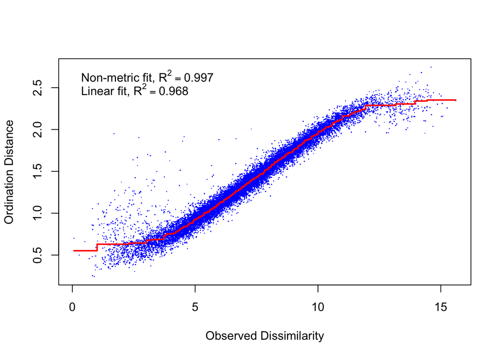

```r
stressplot(meta)
```

*Plots*: in plots, scale is arbitrary and so are the axes. A PCA can be used on the axes to show maximum variation.

*Ugly plots*

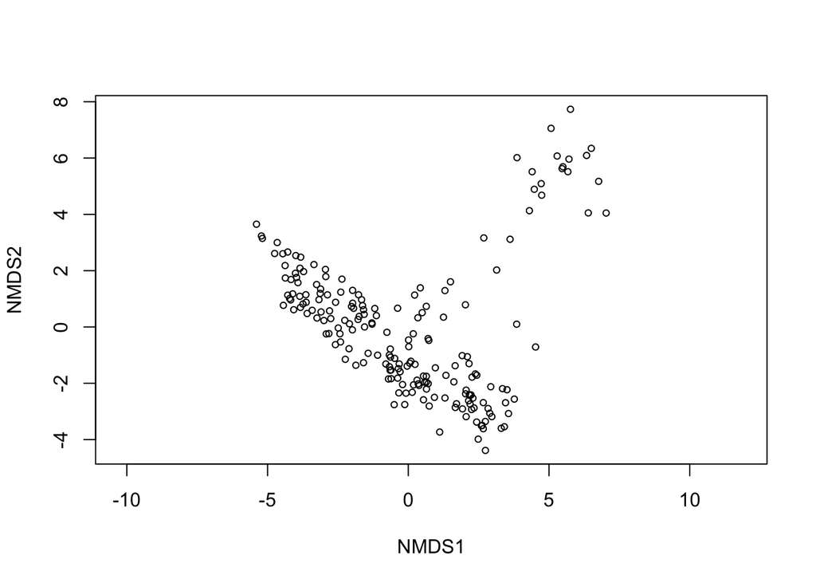

```r
plot(meta, type="p") #point plot
```

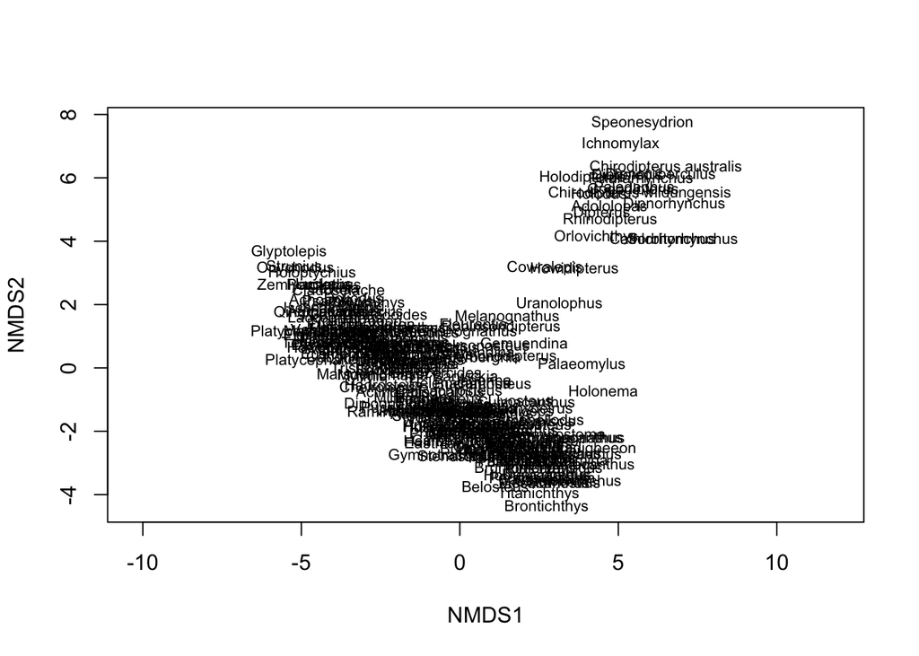

```r
plot(meta, type="t") #text plot
```

```r
#Species scores not available means that we didn't compute the wascores (weighted average scores for species). Wascores refer to species abundance, which we wasn't needed here because there was one representant of each genus.
```

*GGplot* *Figure 2*

```r
#A little bit of formatting
fish_scores<-as.data.frame(scores(meta))#will extract the scores
fish_scores$group<-fish$Group
fish_scores$strat<-fish$Stratigraphic.range
head(fish_scores)
```

```
##                    NMDS1      NMDS2    NMDS3      NMDS4       NMDS5
## Atopacanthus  -3.9710064  1.7601365 2.232413  0.8092336  0.63368369
## Brochoadmones -1.7672029  1.1441706 3.268632  2.8958472 -2.80772901
## Cassidiceps    1.6644470 -1.3765758 2.158082 -1.1406976 -1.39084062
## Cheiracanthus  2.1948930 -2.7374369 5.672558 -1.2070143 -2.12984522
## Diplacanthus   2.2953346 -2.5273410 1.023806 -1.1078903 -0.02641301
## Climatius     -0.3793315  0.6658207 2.336104  4.5514687 -3.69395093
##                    NMDS6      NMDS7       NMDS8      NMDS9     NMDS10
## Atopacanthus  -3.2131753  1.7370945  0.92867558 -0.4457217 -0.4691593
## Brochoadmones -0.5257343  0.3276082  1.47035058 -2.5973611 -1.1002943
## Cassidiceps   -0.7861397 -0.1596289  0.33683096  0.2873570 -0.3311299
## Cheiracanthus -1.6538360 -0.8717801 -0.03382691  0.1075221 -1.1464353
## Diplacanthus  -0.4024286  0.5585204 -0.75923008 -0.1083728  0.1822401
## Climatius     -0.4926452  2.2847770 -0.47221455 -1.1754796  1.6908511
##                    NMDS11      group strat
## Atopacanthus  -0.88286828 Acanthodii   Giv
## Brochoadmones  0.47007498 Acanthodii   Loc
## Cassidiceps   -0.03401033 Acanthodii   Loc
## Cheiracanthus  0.01198979 Acanthodii   Eif
## Diplacanthus  -1.01801810 Acanthodii   Eif
## Climatius      1.53399306 Acanthodii   Sil
```

```r
#Here we're just renaming the labels to use the full name instead of the abbreviation
levels(fish_scores$strat)[levels(fish_scores$strat)=="Sil"] <- "Silurian"
levels(fish_scores$strat)[levels(fish_scores$strat)=="Loc"] <- "Lockhovian"
levels(fish_scores$strat)[levels(fish_scores$strat)=="Pra"] <- "Pragian"
levels(fish_scores$strat)[levels(fish_scores$strat)=="Ems"] <- "Emsian"
levels(fish_scores$strat)[levels(fish_scores$strat)=="Eif"] <- "Eifelian"
levels(fish_scores$strat)[levels(fish_scores$strat)=="Giv"] <- "Givetian"
levels(fish_scores$strat)[levels(fish_scores$strat)=="Fra"] <- "Frasnian"
levels(fish_scores$strat)[levels(fish_scores$strat)=="Fam"] <- "Famennian"
head(fish_scores, 4)
```

```
##                   NMDS1     NMDS2    NMDS3      NMDS4      NMDS5
## Atopacanthus  -3.971006  1.760136 2.232413  0.8092336  0.6336837
## Brochoadmones -1.767203  1.144171 3.268632  2.8958472 -2.8077290
## Cassidiceps    1.664447 -1.376576 2.158082 -1.1406976 -1.3908406
## Cheiracanthus  2.194893 -2.737437 5.672558 -1.2070143 -2.1298452
##                    NMDS6      NMDS7       NMDS8      NMDS9     NMDS10
## Atopacanthus  -3.2131753  1.7370945  0.92867558 -0.4457217 -0.4691593
## Brochoadmones -0.5257343  0.3276082  1.47035058 -2.5973611 -1.1002943
## Cassidiceps   -0.7861397 -0.1596289  0.33683096  0.2873570 -0.3311299
## Cheiracanthus -1.6538360 -0.8717801 -0.03382691  0.1075221 -1.1464353
##                    NMDS11      group      strat
## Atopacanthus  -0.88286828 Acanthodii   Givetian
## Brochoadmones  0.47007498 Acanthodii Lockhovian
## Cassidiceps   -0.03401033 Acanthodii Lockhovian
## Cheiracanthus  0.01198979 Acanthodii   Eifelian
```

*Ggplot it!*

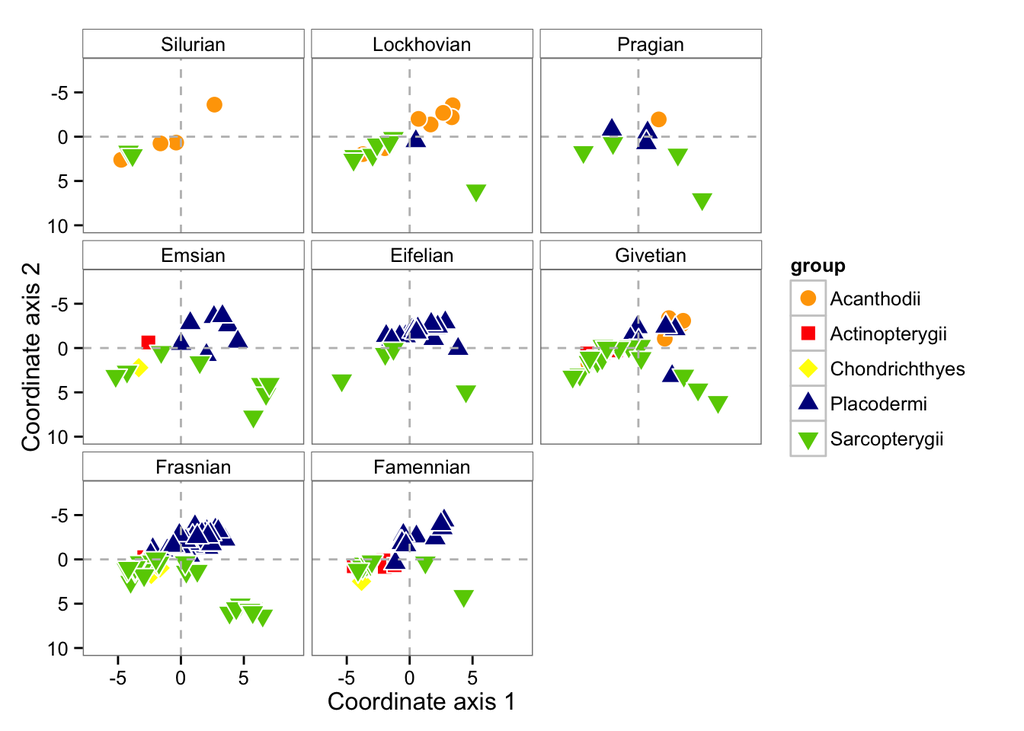

```r
library(ggplot2)
ggfish<- ggplot(transform(fish_scores, strat=factor(strat, levels=c("Silurian", "Lockhovian", "Pragian", "Emsian", "Eifelian", "Givetian", "Frasnian", "Famennian")))) + geom_point(data=fish_scores, aes(x=NMDS1, y=NMDS2, shape=group, fill=group, colour=group), size=4) + theme_bw() + scale_color_manual(labels = c("Acanthodii", "Actinopterygii", "Chondrichthyes",  "Placodermi","Sarcopterygii"), values= rep("white", 5)) + scale_x_continuous(limits=c(-7,9)) + scale_y_reverse(limits=c(10,-8)) + scale_shape_manual(labels = c("Acanthodii", "Actinopterygii", "Chondrichthyes",  "Placodermi","Sarcopterygii"), values = c(21, 22, 23, 24, 25)) + scale_fill_manual(labels = c("Acanthodii", "Actinopterygii", "Chondrichthyes",  "Placodermi","Sarcopterygii"), values=c("orange", "red", "yellow", "darkblue", "chartreuse3")) + theme(panel.grid.major = element_blank(), panel.grid.minor = element_blank(), strip.background = element_rect(fill="white")) + geom_hline(x=0, linetype="dashed", color="grey") + geom_vline(y=0, linetype="dashed", color="grey") + xlab("Coordinate axis 1") + ylab("Coordinate axis 2")+ facet_wrap (~strat)
ggfish
```

*Figure S9* : CA1 and CA3, with convex hulls

```r
#gather the data to form the hulls
library(dplyr)
```

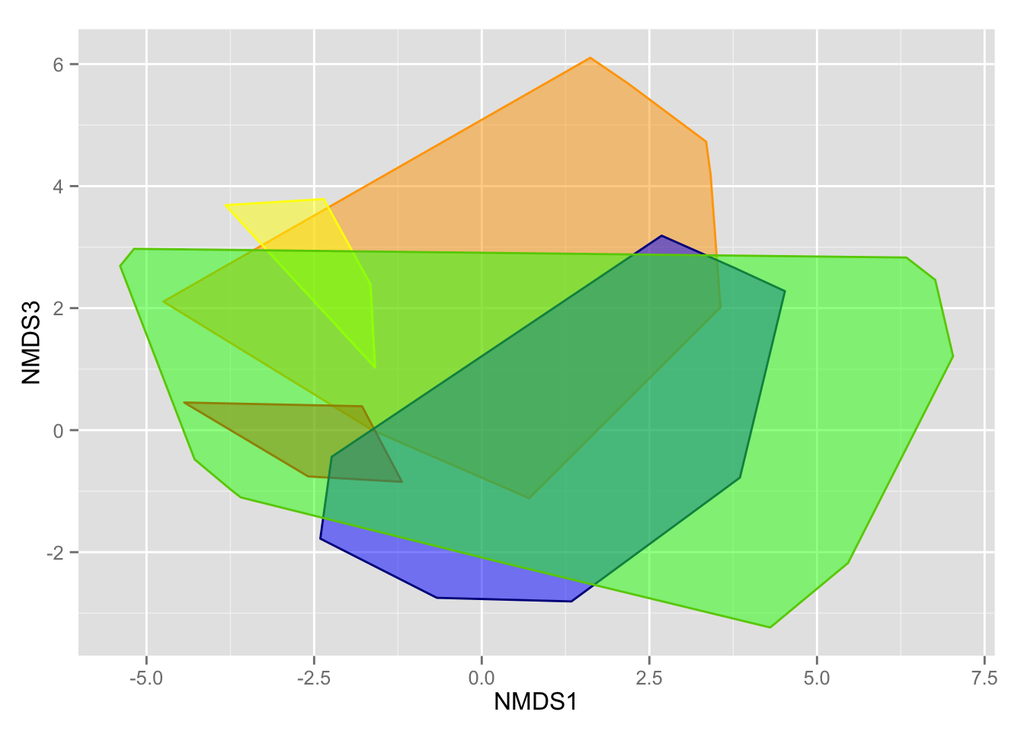

```r
fish_hull<- select(fish_scores, NMDS1, NMDS2, group)
hullAca <- fish_scores[fish_scores$group=="Acanthodii",] %>%
  select(NMDS1, NMDS3)
hullAct <- fish_scores[fish_scores$group=="Actinopterygii",] %>%
  select(NMDS1, NMDS3)
hullCho <- fish_scores[fish_scores$group=="Chondrichthyes",] %>%
  select(NMDS1, NMDS3)
hullPla <- fish_scores[fish_scores$group=="Placodermi",] %>%
  select(NMDS1, NMDS3)
hullSar <- fish_scores[fish_scores$group=="Sarcopterygii",] %>%
  select(NMDS1, NMDS3)

#plot the hulls first
fish_prehull<- ggplot() + geom_polygon(inherit.aes=F, data=hullAca[chull(hullAca),], aes(x=NMDS1, y=NMDS3), alpha=0.5, fill="orange", linetype=1, color="orange") + geom_polygon(inherit.aes=F, data=hullAct[chull(hullAct),], aes(x=NMDS1, y=NMDS3), alpha=0.5, fill="red", linetype=1, color="red") + geom_polygon(inherit.aes=F, data=hullCho[chull(hullCho),], aes(x=NMDS1, y=NMDS3), alpha=0.5, fill="yellow", linetype=1, color="yellow") + geom_polygon(inherit.aes=F, data=hullPla[chull(hullPla),], aes(x=NMDS1, y=NMDS3), alpha=0.5, fill="blue", linetype=1, color="darkblue") + geom_polygon(inherit.aes=F, data=hullSar[chull(hullSar),], aes(x=NMDS1, y=NMDS3), alpha=0.5, fill="green", linetype=1, color="chartreuse3")
fish_prehull
```

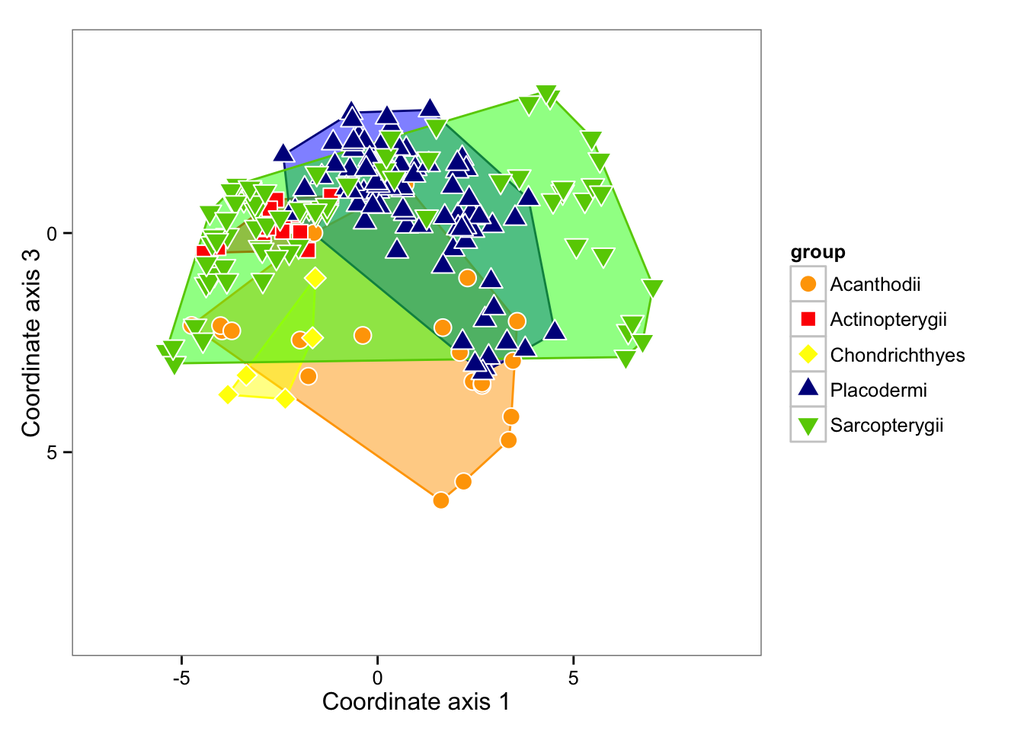

```r
final_fish<- fish_prehull + geom_point(data=fish_scores, aes(x=NMDS1, y=NMDS3, shape=group, fill=group, colour=group), size=4) + theme_bw() + scale_color_manual(labels = c("Acanthodii", "Actinopterygii", "Chondrichthyes",  "Placodermi","Sarcopterygii"), values= rep("white", 5)) + scale_x_continuous(limits=c(-7,9)) + scale_y_reverse(limits=c(9,-4)) + scale_shape_manual(labels = c("Acanthodii", "Actinopterygii", "Chondrichthyes",  "Placodermi","Sarcopterygii"), values = c(21, 22, 23, 24, 25)) + scale_fill_manual(labels = c("Acanthodii", "Actinopterygii", "Chondrichthyes",  "Placodermi","Sarcopterygii"), values=c("orange", "red", "yellow", "darkblue", "chartreuse3")) + theme(panel.grid.major = element_blank(), panel.grid.minor = element_blank(), strip.background = element_rect(fill="white")) + xlab("Coordinate axis 1") + ylab("Coordinate axis 3") + geom_hline(x=0, linetype="dashed", color="grey") + geom_vline(y=0, linetype="dashed", color="grey")
final_fish
```

*Conclusion*: Although the gnathostomes became more taxonomically diverse, their jaws morphology remains relatively stable through time and cannot be linked to the rarification of the agnathostomes during the Emsian. Overall, there is very little innovation and diversification within this group.